# Tarea 5-R-UDP Lourido-Nuñez-Poblete

# Pregunta 2 (*50 puntos*)

1. Descargue el precio de las acciones de Microsoft (“MSFT”) y Apple (“AAPL”) desde Enero del 2000 hasta Agosto del 2018 con periodicidad mensual.

```r
Apple = pdfetch_YAHOO("AAPL", fields = "close", from = as.Date("2000-01-01"),
                      to = as.Date("2018-08-31"), interval = "1m")
Microsoft = pdfetch_YAHOO("MSFT", fields ="close", from = as.Date("2000-01-01"),
                          to = as.Date("2018-08-31"), interval = "1m")
```

2. Utilizando los datos de 2.1, construya una función que permita:
1. Calcular los retornos.
2. Graficar los retornos y retornos acumulados.
3. Testear normalidad utilizando Jarque-Bera (JB)

```r
funcion_finanzas = function(x,return,graph,norm) {
  if (return=="yes") {
    # Retornos
    x$Retornos<- periodReturn(x, type="log")
    print(x$Retornos)
  }
  if (return=="no") {
    # Retornos Acumulados
    x$Retornos <- periodReturn(x, type="arithmetic")
    print(x$Retornos)
  }
  if (graph=="tipo1") {
    #Gráfico Retornos
    plot.ts(x$Retornos, main = "Retornos", col= "blue")
  }
  if (graph=="tipo2") {
    #Gráfico Retornos Acumulados
    x$Retornos_acum <- cumsum(x$Retornos)
    plot.ts(x$Retornos_acum, main = "Retornos Acumulados", col= "red")
  }
  if (norm=="yes") {
    Skew <- (sum((x - mean(x))^3)/length(x))/(sum((x - mean(x))^2)/length(x))^(3/2)
    Kur <- length(x) * sum((x - mean(x))^4)/(sum((x - mean(x))^2)^2)
    JB <- (length(x)/6) * (Skew^2 + 0.25 * ((Kur - 3)^2))
    pval <- 1 - pchisq(JB, df = 2)
    if (pval<0.05) {
      print("Se rechaza H0 de distribución normal")
      print(paste(JB, Skew, Kur))
    }
    else {
      print("No se rechaza H0 de distribución normal")
    }
  }
}

funcion_finanzas(Apple,return = "yes", graph = "tipo1",norm="yes")
```

[output not shown]

# Pregunta 3 (*30 puntos*)

1. Calcule E( ˆ 1) y var( ˆ 1) para muestras de tamaños 50, 100, 500, 1000. ¿Existe sesgo?, ¿Desaparece el sesgo a medida que el tamaño de la muestra aumenta?

En un principio generamos los parámetros.

```r
set.seed(123)
reps = 10000

betas = matrix(NA, nrow = reps, ncol = 8)

beta0 = 2
beta1 = 2.5
beta2 = 1

n = c(50, 100, 500, 1000)

for (j in 1:length(n)) {
  X1=rnorm(n[j],20,1)
  X2=0.8*X1
  for (i in 1:reps) {
    u= beta2*X2 + rnorm(n[j],0,1)
    Y = beta0 + beta1*X1 + u
    model = lm(Y~X1)
    betas[i,j] = model$coef[1]
    betas[i,j+4] = model$coef[2]
  }
}

betas_df <- data.frame(betas)

Ebeta50=mean(betas_df[,5])
Ebeta100=mean(betas_df[,6])
Ebeta500=mean(betas_df[,7])
Ebeta1000=mean(betas_df[,8])

Vbeta50=var(betas_df[,5])
Vbeta100=var(betas_df[,6])
Vbeta500=var(betas_df[,7])
Vbeta1000=var(betas_df[,8])
```

Para ver si existe sesgo, debemos calcular el beta del modelo poblacional.

```r
betas1 = matrix(NA, nrow = reps, ncol = 12)

for (j in 1:length(n)) {
  X1=rnorm(n[j],20,1)
  X2=runif(n[j],0,1)
  for (i in 1:reps) {
    u= rnorm(n[j],0,1)
    Y = beta0 + beta1*X1 + beta2*X2 + u
    model = lm(Y~X1+X2)
    betas1[i,j] = model$coef[1]
    betas1[i,j+4] = model$coef[2]
    betas1[i,j+8] = model$coef[3]
  }
}

betas_df1 <- data.frame(betas1)

Ebeta50pob=mean(betas_df1[,5])
Ebeta100pob=mean(betas_df1[,6])
Ebeta500pob=mean(betas_df1[,7])
Ebeta1000pob=mean(betas_df1[,8])
Ebetapob = mean(Ebeta50,Ebeta100,Ebeta500,Ebeta1000)

sesgo50 = Ebeta50 - Ebetapob
sesgo100 = Ebeta100 - Ebetapob
sesgo500 = Ebeta500 - Ebetapob
sesgo1000 = Ebeta1000 - Ebetapob
```

```r
sesgosbeta1 = data.frame(sesgo50, sesgo100, sesgo500, sesgo1000)
knitr::kable(sesgosbeta1)
```

[output not shown]

Los parámetros estimados son sesgados, y no existe evidencia de que a un mayor tamaño de muestra disminuya el sesgo. La solución a omisión de variables relevantes es incluirlas en la regresión.

2. Grafique la distribución de ˆ 1 para tamaños de muestra n = 50, 100, 500, 1000

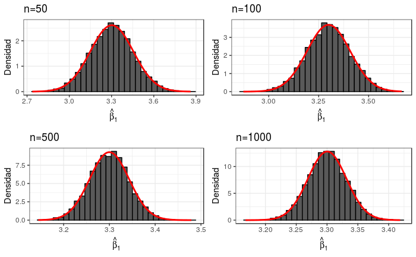

```r
g11 <- ggplot(betas_df) +
  geom_histogram(aes(betas_df[,5], y=..density..), col="black", bins = 30) +
  stat_function(fun=dnorm, args=list(mean=mean(betas_df[,5]), sd=sd(betas_df[,5])),
                geom="line", colour="red", size=1) +
  ylab("Densidad") +   ggtitle("n=50") + xlab(expression(hat(beta)[1])) +
  theme_bw()

g21 <- ggplot(betas_df) +
  geom_histogram(aes(betas_df[,6], y=..density..), col="black", bins = 30) +
  stat_function(fun=dnorm, args=list(mean=mean(betas_df[,6]), sd=sd(betas_df[,6])),
                geom="line", colour="red", size=1) +
  ylab("Densidad") +   ggtitle("n=100") + xlab(expression(hat(beta)[1])) +
  theme_bw()

g31 <- ggplot(betas_df) +
  geom_histogram(aes(betas_df[,7], y=..density..), col="black", bins = 30) +
  stat_function(fun=dnorm, args=list(mean=mean(betas_df[,7]), sd=sd(betas_df[,7])),
                geom="line", colour="red", size=1) +
  ylab("Densidad") +   ggtitle("n=500") + xlab(expression(hat(beta)[1])) +
  theme_bw()

g41 <- ggplot(betas_df) +
  geom_histogram(aes(betas_df[,8], y=..density..), col="black", bins = 30) +
  stat_function(fun=dnorm, args=list(mean=mean(betas_df[,8]), sd=sd(betas_df[,8])),
                geom="line", colour="red", size=1) +
  ylab("Densidad") +   ggtitle("n=1000") + xlab(expression(hat(beta)[1])) +
  theme_bw()

grid.arrange(g11, g21, g31, g41, nrow=2, ncol=2)
```

3. Si x2  U[0, 1], ¿Cómo cambian los resultados que obtuviste en (a) y (b)?

```r
betas2 = matrix(NA, nrow = reps, ncol = 8)

for (j in 1:length(n)) {
  X1=rnorm(n[j],20,1)
  X2=runif(n[j],0,1)
  for (i in 1:reps) {
    u= X2 + rnorm(n[j],0,1)
    Y = beta0 + beta1*X1 + u
    model = lm(Y~X1)
    betas2[i,j] = model$coef[1]
    betas2[i,j+4] = model$coef[2]
  }
}

betas_df2 <- data.frame(betas2)
```

A continuación graficamos para ver los resultados.

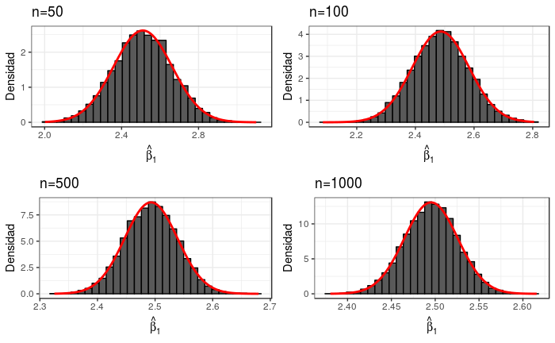

```r
h11 <- ggplot(betas_df2) +
  geom_histogram(aes(betas_df2[,5], y=..density..), col="black", bins = 30) +
  stat_function(fun=dnorm, args=list(mean=mean(betas_df2[,5]), sd=sd(betas_df2[,5])),
                geom="line", colour="red", size=1) +
  ylab("Densidad") +   ggtitle("n=50") + xlab(expression(hat(beta)[1])) +
  theme_bw()

h21 <- ggplot(betas_df2) +
  geom_histogram(aes(betas_df2[,6], y=..density..), col="black", bins = 30) +
  stat_function(fun=dnorm, args=list(mean=mean(betas_df2[,6]), sd=sd(betas_df2[,6])),
                geom="line", colour="red", size=1) +
  ylab("Densidad") +   ggtitle("n=100") + xlab(expression(hat(beta)[1])) +
  theme_bw()

h31 <- ggplot(betas_df2) +
  geom_histogram(aes(betas_df2[,7], y=..density..), col="black", bins = 30) +
  stat_function(fun=dnorm, args=list(mean=mean(betas_df2[,7]), sd=sd(betas_df2[,7])),
                geom="line", colour="red", size=1) +
  ylab("Densidad") +   ggtitle("n=500") + xlab(expression(hat(beta)[1])) +
  theme_bw()

h41 <- ggplot(betas_df2) +
  geom_histogram(aes(betas_df2[,8], y=..density..), col="black", bins = 30) +
  stat_function(fun=dnorm, args=list(mean=mean(betas_df2[,8]), sd=sd(betas_df2[,8])),
                geom="line", colour="red", size=1) +
  ylab("Densidad") +   ggtitle("n=1000") + xlab(expression(hat(beta)[1])) +
  theme_bw()

grid.arrange(h11, h21, h31, h41, nrow=2, ncol=2)
```